# How Instagram Advertising Influences Consumer Interest

## Introduction

Instagram ads show up in a lot of different formats these day like single images, carousel posts, and short videos or reels. Businesses use these formats to try grab attention, boost engagement, and get people interested in their products.

In this visual data story, I look at observational Instagram ad data to see how things like ad format, popularity, and timing might influence consumer behaviour.

The main questions I’m trying to explore are:

- Which ad format seems to lead to higher purchase likelihood?
- Do ads with more likes actually seem more persuasive?
- When during the day are Instagram ads most commonly seen?

Overall, this helps give a bit of insight into how social media advertising might be shaping what people click on or are interested in.

## Which Ad Format Is Most Effective?

Different ad formats are designed to catch attention in different ways. Video and reel ads usually mix motion, sound, and storytelling, while carousel ads let users swipe through multiple images. Single-image ads, on the other hand, rely on just one visual to do all the work.

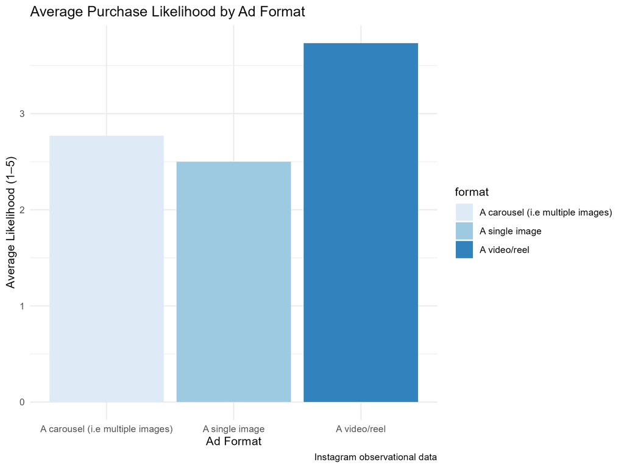

The results suggest that video or reel ads tend to have the highest average purchase likelihood. Carousel ads also perform a bit better than single-image ones, but not by a huge margin.

This kind of makes sense, moving content is usually more engaging, and people might just spend more time watching reels compared to static posts. That extra attention could make the ad more persuasive overall.

## Do Popular Ads Influence Consumers?

On Instagram, you often see ads with a lot of likes, and it kind of makes them feel more trustworthy or popular. This section looks at whether that actually connects to how likely people are to engage with the ad.

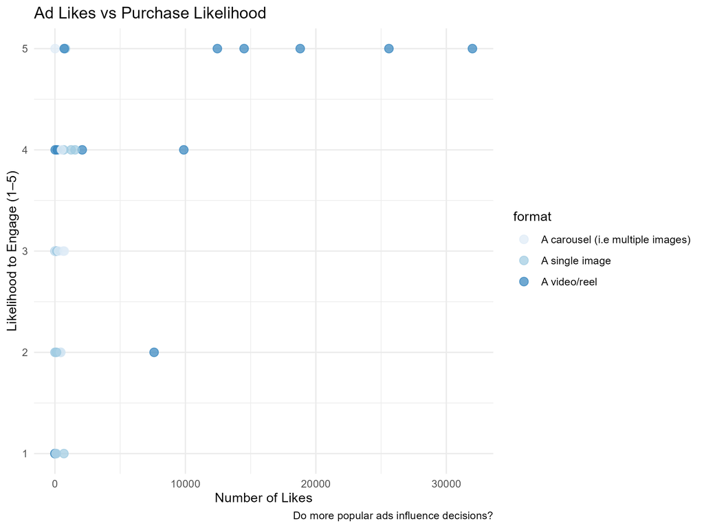

Scatterplot displaying advertisement likes on the x-axis and purchase likelihood on the y-axis. Data points are coloured by advertisement format. Most points are spread across the graph with no strong linear relationship, although several highly liked advertisements are associated with higher likelihood scores.

So popularity alone doesn’t really guarantee influence. Things like what the ad is actually showing, the format, and even personal interest probably matter a lot more.

## When Are Instagram Ads Most Common?

Timing might also play a role in how often people notice ads while scrolling. By looking at timestamp data, we can see when ads were most often recorded.

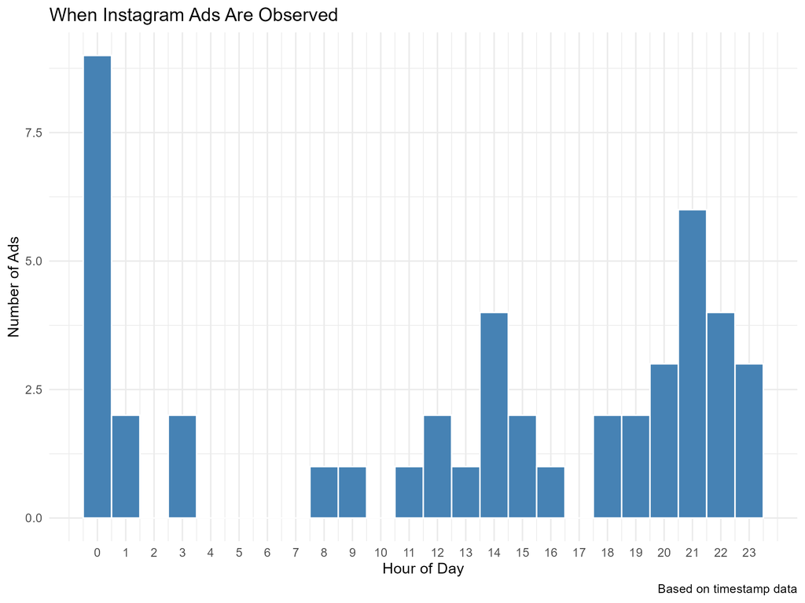

This probably lines up with when people are most active on Instagram, so advertisers might also be targeting those peak usage times without it being super obvious.

## Conclusion

Overall, it looks like ad format might play a role in how appealing an Instagram ad is, with videos and reels doing the best in this dataset.

Likes don’t seem to strongly predict purchase likelihood on their own, which suggests that popularity isn’t everything. Timing also shows a clear pattern, with most ads being observed during more active hours of the day.

Since this is just observational data (and a fairly small dataset), it doesn’t prove anything for sure, but it does give a pretty interesting snapshot of how Instagram advertising might influence user behaviour.